# Practical Machine Learning Course Project - Human Activity Recognition

William Lai

14 March 2018

## 1. Introduction

In this report, we will use the Human Activity Recognition (HAR) dataset to train the prediction model and select the best model to predict activity class of 20 different test cases.

The HAR dataset contains data from accelerometers on the belt, forearm, arm and dumbell of 6 participants. These data could be used to quantified self movement. Participants are asked to perform barbell lifts correctly and incorrectly in 5 different ways.

HAR Dataset Description: http://web.archive.org/web/20161224072740/http:/groupware.les.inf.puc-rio.br/har

## 2. Preparation

### 2.1 Environment

```r
library(rattle)
library(lattice)
library(ggplot2)

library(caret)
library(rpart)
library(gbm)
library(randomForest)

## Improve random forest performance as suggested
library(parallel)
library(doParallel)

cluster <- makeCluster(detectCores() - 1) # convention to leave 1 core for OS
```

### 2.2 Data Loading

The data is loaded directly from the website:

```r
harTrain <- read.csv("https://d396qusza40orc.cloudfront.net/predmachlearn/pml-training.csv")
harTest <- read.csv("https://d396qusza40orc.cloudfront.net/predmachlearn/pml-testing.csv")
```

```r
dim(harTrain)
```

```
## [1] 19622   160
```

```r
dim(harTest)
```

```
## [1]  20 160
```

```r
setdiff(names(harTrain), names(harTest))
```

```
## [1] "classe"
```

```r
setdiff(names(harTest), names(harTrain))
```

```
## [1] "problem_id"
```

Both data contains same number of columns and the only different is that the training data contains the classe column (actual result) while the testing data contains the problem_id column (test case ID).

### 2.3 Data Cleansing

We will remove those predictors that are near zero variance or contain N/A value. They will not be considered as predictors in our prediction.

```r
nzv <- nearZeroVar(harTrain)
harTrain <- harTrain[, -nzv]
harTest <- harTest[, -nzv]

notNa <- colSums(is.na(harTrain)) == 0
harTrain <- harTrain[, notNa]
harTest <- harTest[, notNa]
```

In addition, the timestamp and window columns are not considered as predictors since they are only the occasion that the test taken.

```r
harTrain <- harTrain[, !grepl("^X|timestamp|window", names(harTrain))]
harTest <- harTest[, !grepl("^X|timestamp|window", names(harTest))]
```

The final set of columns used in training is as follow:

```r
names(harTrain)
```

```
##  [1] "user_name"            "roll_belt"            "pitch_belt"
##  [4] "yaw_belt"             "total_accel_belt"     "gyros_belt_x"
##  [7] "gyros_belt_y"         "gyros_belt_z"         "accel_belt_x"
## [10] "accel_belt_y"         "accel_belt_z"         "magnet_belt_x"
## [13] "magnet_belt_y"        "magnet_belt_z"        "roll_arm"
## [16] "pitch_arm"            "yaw_arm"              "total_accel_arm"
## [19] "gyros_arm_x"          "gyros_arm_y"          "gyros_arm_z"
## [22] "accel_arm_x"          "accel_arm_y"          "accel_arm_z"
## [25] "magnet_arm_x"         "magnet_arm_y"         "magnet_arm_z"
## [28] "roll_dumbbell"        "pitch_dumbbell"       "yaw_dumbbell"
## [31] "total_accel_dumbbell" "gyros_dumbbell_x"     "gyros_dumbbell_y"
## [34] "gyros_dumbbell_z"     "accel_dumbbell_x"     "accel_dumbbell_y"
## [37] "accel_dumbbell_z"     "magnet_dumbbell_x"    "magnet_dumbbell_y"
## [40] "magnet_dumbbell_z"    "roll_forearm"         "pitch_forearm"
## [43] "yaw_forearm"          "total_accel_forearm"  "gyros_forearm_x"
## [46] "gyros_forearm_y"      "gyros_forearm_z"      "accel_forearm_x"
## [49] "accel_forearm_y"      "accel_forearm_z"      "magnet_forearm_x"
## [52] "magnet_forearm_y"     "magnet_forearm_z"     "classe"
```

## 3. Training

### 3.1 Training Data Partition

In order to cross-validate the performance of different prediction models, We will split the training data set into 2 sets, training and probe, using random sub-sampling:

```r
inTrain <- createDataPartition(harTrain$classe, p = 0.70, list = F)
training <- harTrain[inTrain, ]
probe <- harTrain[-inTrain, ]
```

### 3.2 Prediction Method Training

We have selected decision tree, random forest and boosting and compare the performance against our dataset. We will first use the training data set to train the models.

```r
fitControl <- trainControl(method = "cv", number = 5, allowParallel = TRUE)
```

#### 3.2.1 Decision Tree

```r
registerDoParallel(cluster)

set.seed(88888)
dtFit <- train(classe ~ ., data = training, method = "rpart", trControl = fitControl)

registerDoSEQ()
```

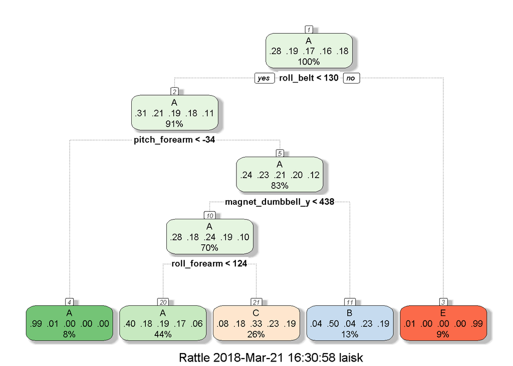

```r
fancyRpartPlot(dtFit$finalModel)
```

#### 3.2.2 Random Forest

```r
registerDoParallel(cluster)

set.seed(88888)
rfFit <- train(classe ~ ., data = training, method = "rf", trControl = fitControl, importance = TRUE)
stopCluster(cluster)

registerDoSEQ()
```

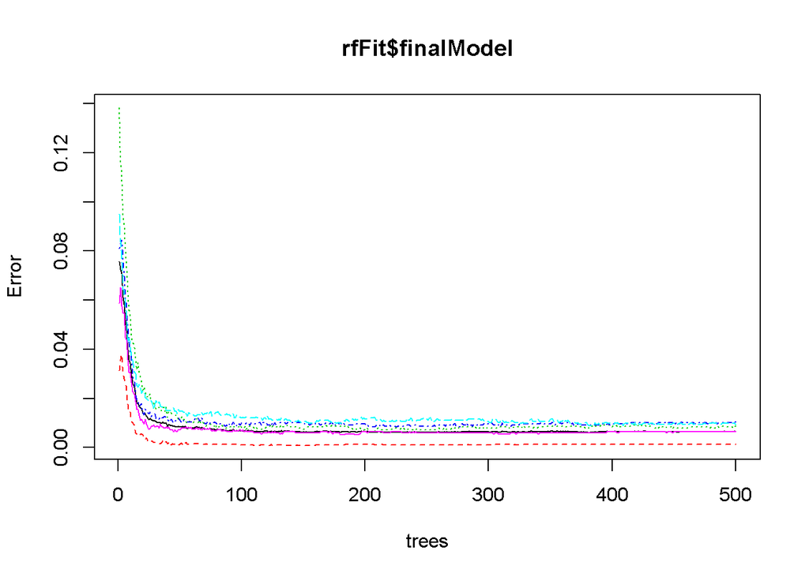

```r
plot(rfFit$finalModel)
```

#### 3.2.3 Boosting

```r
registerDoParallel(cluster)

set.seed(88888)
btFit <- train(classe ~ ., data = training, method = "gbm", trControl = fitControl, verbose = FALSE)
stopCluster(cluster)

registerDoSEQ()
```

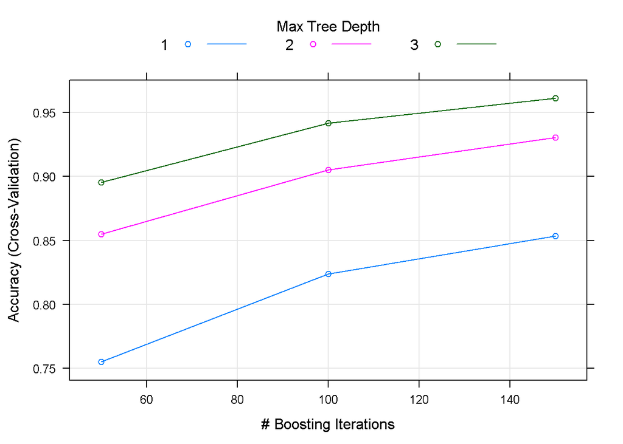

```r
plot(btFit)
```

### 3.3 Cross Validation

We will then perform the cross validation using the probe dataset.

```r
dtCv <- predict(dtFit, newdata = probe)
dtCm <- confusionMatrix(probe$classe, dtCv)

rfCv <- predict(rfFit, newdata = probe)
rfCm <- confusionMatrix(probe$classe, rfCv)

btCv <- predict(btFit, newdata = probe)
btCm <- confusionMatrix(probe$classe, btCv)
```

| Model | Accuracy | Out of Sample Error |
| --- | --- | --- |
| Decision Tree | 0.4943076 | 0.5056924 |
| Random Forest | 0.997791 | 0.002209 |
| Boosting | 0.9714528 | 0.0285472 |

From the above data, both random forest and boosting models out-perform the decision tree model. Random forest is slightly more accurate than boosting. As a result, we will use random forest as our prediction model.

The confusion matrix of random forest model is as below:

```r
rfCm$table
```

```
##           Reference
## Prediction    A    B    C    D    E
##          A 1672    1    0    0    1
##          B    3 1135    1    0    0
##          C    0    4 1022    0    0
##          D    0    0    3  961    0
##          E    0    0    0    0 1082
```

The random forest model has identified number of predictors:

```r
varImp(rfFit)
```

```
## rf variable importance
##
##   variables are sorted by maximum importance across the classes
##   only 20 most important variables shown (out of 57)
##
##                       A     B      C     D     E
## pitch_forearm     65.40 76.86 100.00 60.28 63.74
## roll_belt         84.75 99.81  90.92 90.47 99.43
## pitch_belt        31.23 95.47  71.60 52.30 44.91
## magnet_dumbbell_y 71.24 63.00  78.26 59.23 55.96
## magnet_dumbbell_z 76.54 59.64  74.58 54.46 53.41
## yaw_belt          69.79 66.34  70.10 74.10 53.73
## roll_forearm      52.41 46.51  49.02 40.11 42.32
## accel_forearm_x   23.86 39.97  37.79 48.55 40.37
## gyros_dumbbell_y  41.13 33.49  48.23 32.24 29.24
## gyros_belt_z      26.76 31.53  35.13 27.86 46.69
## yaw_arm           45.02 36.67  32.31 37.96 24.90
## accel_dumbbell_y  40.60 33.83  42.78 33.54 32.53
## magnet_belt_z     28.40 40.38  28.71 34.68 33.37
## roll_dumbbell     26.98 36.75  27.20 29.10 32.78
## magnet_belt_y     18.87 36.49  31.60 25.29 29.10
## magnet_belt_x     20.70 35.97  31.03 20.73 31.67
## accel_dumbbell_z  26.07 35.03  25.78 31.63 35.28
## pitch_arm         15.48 35.15  22.27 19.69 26.44
## gyros_arm_y       28.79 33.91  27.05 34.26 25.24
## magnet_forearm_z  32.21 31.39  30.42 30.66 34.09
```

## 4. Prediction

Since we have chosen random forest as our prediction model, we will feed the testing dataset and generate the prediction result of 20 different test cases.

```r
predict <- predict(rfFit, newdata = harTest)

data.frame(
  problem_id = harTest$problem_id,
  predict_classe = predict
)
```

```
##    problem_id predict_classe
## 1           1              B
## 2           2              A
## 3           3              B
## 4           4              A
## 5           5              A
## 6           6              E
## 7           7              D
## 8           8              B
## 9           9              A
## 10         10              A
## 11         11              B
## 12         12              C
## 13         13              B
## 14         14              A
## 15         15              E
## 16         16              E
## 17         17              A
## 18         18              B
## 19         19              B
## 20         20              B
```

## 5. Conclusion

We have compared 3 prediction models for the HAR data set. We have selected to use random forest for the testing data prediction due to it high accuracy (0.997791). The prediction result of 20 different test cases are then generated using this model which could be found in the prediction section.